# Project Insights and Visualizations.

### Overview

This document is an insights and visualizations report for the Udacity data wrangling project, which involved interacting with tweets data for the WeRateDogs account that rates people's dogs with a humorous comment about the dog. The process of interacting with the tweets data involved gathering the data, that is gathering the data from various sources, assessing the data to view facts about the data, while gathering insights about the data, cleaning the data, and executing a simplistic exploratory data analysis to vizualise some interesting patterns in the cleaned data.

After the wrangling process, I had a couple of wuestions that had to be answered.

1. What is WeRateDog's monthly trend of tweet posts?
2. What is the engagement rate with the tweets basing on the favourites and retweets per tweet over the given months?
3. Which dog stage is retweeted, and favourited the most?

To answer these questions, I came up with the following graphic representations to answer the questions that I had.

### 1. What is WeRateDog's monthly trend of tweet posts?

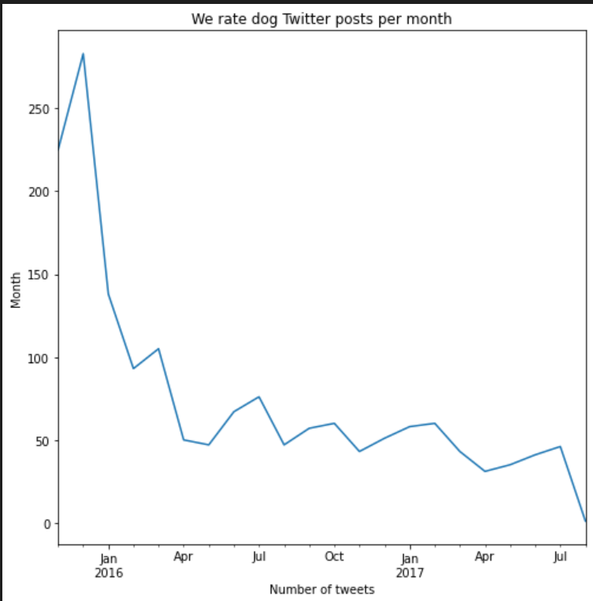

### 2. What is the engagement rate with the tweets basing on the favourites and retweets per tweet over the given months?

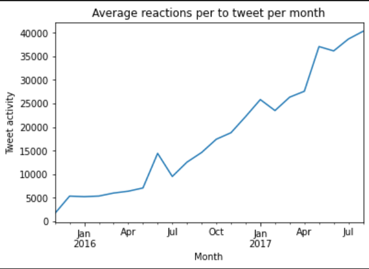

### 3. Which dog stage is retweeted, and favourited the most?

I had to look into the fact that different dog stages drive the attention of the multitude. A quick insight into this question was meant to answer the question of what dog stage would be ideal or liked?. The answer was in the analysis, in which I grouped the dog stage and looked at the mean number of favourites and retweets for each dog stage. The investigation of the mean number of favourites for the dog stage showed that the **Puppo**, had the highest mean number of favourites, and the **pupper** had the least mean number of favourites. This can be seen in the graph below.

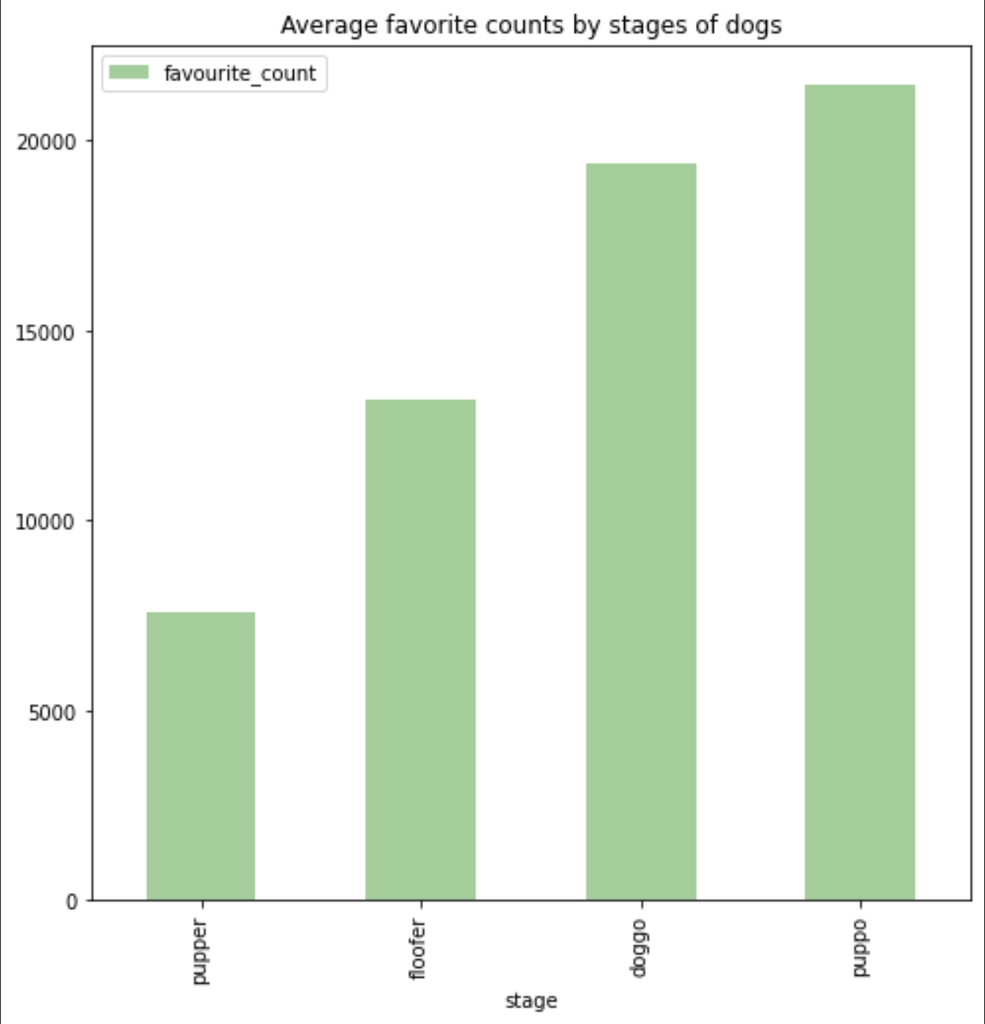

As for the investigation of the mean number of retweets for the different dog stages, the **Doggo** on average had the highest number of retweets, and the **Pupper** had the lowest number of retweets. This is shown below.

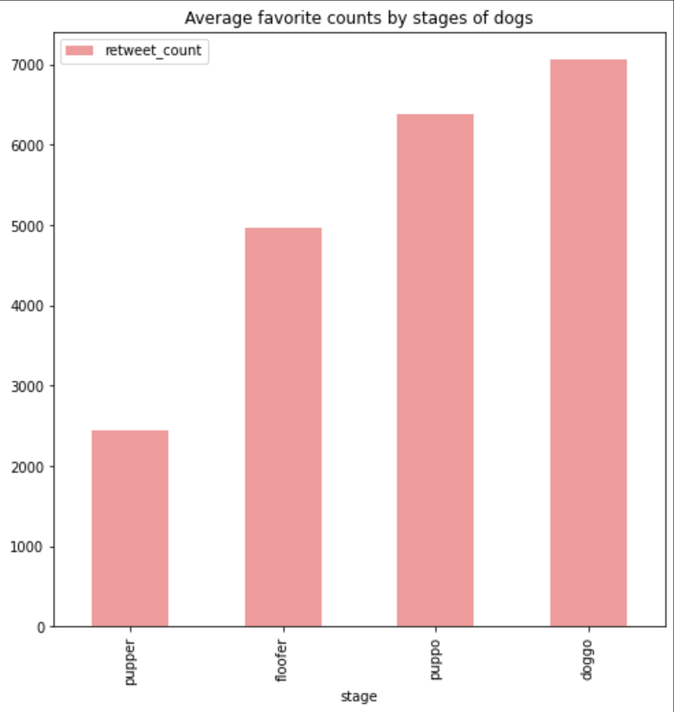

Based on the investigative anaylsis, a conclusion can be drawn that a dog within the **Pupper** stage is not really liked as much.